# Final Project

Nisfu Lailatul Maghfiroh  
Rahmandita Putri Alisya  
Rina Lia Aryati  
FGA - DTS 2019 Kelas D

# 1. Telco Customer Churn

Data yang digunakan adalah Telco Customer Churn dari IBM Sample Dataset. Hal ini merupakan suatu metrik untuk mengevaluasi pertumbuhan bisnis yakni peningkatan pentingnya strategi pemasaran dan kesadaran perilaku customer dalam beberapa tahun terakhir. Customer Churn berfokus pada perilaku customer telekomunikasi yang lebih cenderung berhenti berlangganan provider tertentu atau pindah ke layanan provider lain (churn). [Sumber](https://rstudio-pubs-static.s3.amazonaws.com/453471_1fd6bcc407eb4e2ba49b616f2886cc5b.html)

| No. | Variabel | Keterangan |
| --- | --- | --- |
| 1. | Senior Citizen | Customer yang berusia 60-80 tahun (0,1) |
| 2. | Patner | Customer yang memiliki patner atau tidak dalam berlangganan (Yes,No) |
| 3. | Dependents | Tanggungan customer (Yes,No) |
| 4. | Tenure | Berapa lama menggunakan layanan provider |
| 5. | Phone Service | Customer memiliki layanan telepon atau tidak (Yes,No) |
| 6. | SMultiple Lines | Customer memiliki satu saluran atau lebih (Yes,No) |
| 7. | Internet Service | Layanan internet customer (DSL, Fiber optic, No) |
| 8. | Online Backup | Backup Online yang dimiliki customer (Yes,No) |
| 9. | Device Protection | Perlindungan perangkat customer (Yes,No) |
| 10. | Tech Support | Dukungan teknis customer (Yes,No) |
| 12. | Streaming TV | Customer menggunakan layanan TV streaming atau tidak (Yes,No) |
| 13. | Streaming Movies | Customer menggunakan layanan streaming film atau tidak (Yes,No) |
| 14. | Contract | Ketentuan kontrak customer (Bulan ke bulan, Satu tahun, Dua tahun) |
| 15. | Paperless Billing | Pembayaran tagihan customer dengan kertas atau tidak (Yes,No) |
| 16. | Payment Method | Metode pembayaran customer(cek elektronik,cek lewat pos,transfer bank,kartu kredit) |
| 17. | Monthly Charges | Jumlah yang dibayar customer setiap bulan |
| 18. | Total Charges | Jumlah total yang dibayar customer |
| 19. | Churn | Customer yang berhenti berlangganan provider (Yes,No) |
| 20. | Customer Id | Id Customer |
| 21. | Gender | Jenis kelamin (pria,wanita) </p |

```python
#library
import pandas as pd
import numpy as np
import seaborn as sns
import matplotlib.pyplot as plt
import matplotlib.ticker as mtick
plt.style.use('ggplot')
```

```python
# import data dari jupyter directory
data=pd.read_csv('data_dts/Telco-Customer-Churn.csv')
print ('Rows of dataset :', len(data.index))
print ('Columns of dataset :', len(data.columns))
data.head()
```

```
Rows of dataset : 7043
Columns of dataset : 21
```

|  | customerID | gender | SeniorCitizen | Partner | Dependents | tenure | PhoneService | MultipleLines | InternetService | OnlineSecurity | ... | DeviceProtection | TechSupport | StreamingTV | StreamingMovies | Contract | PaperlessBilling | PaymentMethod | MonthlyCharges | TotalCharges | Churn |
| --- | --- | --- | --- | --- | --- | --- | --- | --- | --- | --- | --- | --- | --- | --- | --- | --- | --- | --- | --- | --- | --- |
| 0 | 7590-VHVEG | Female | 0 | Yes | No | 1 | No | No phone service | DSL | No | ... | No | No | No | No | Month-to-month | Yes | Electronic check | 29.85 | 29.85 | No |
| 1 | 5575-GNVDE | Male | 0 | No | No | 34 | Yes | No | DSL | Yes | ... | Yes | No | No | No | One year | No | Mailed check | 56.95 | 1889.5 | No |
| 2 | 3668-QPYBK | Male | 0 | No | No | 2 | Yes | No | DSL | Yes | ... | No | No | No | No | Month-to-month | Yes | Mailed check | 53.85 | 108.15 | Yes |
| 3 | 7795-CFOCW | Male | 0 | No | No | 45 | No | No phone service | DSL | Yes | ... | Yes | Yes | No | No | One year | No | Bank transfer (automatic) | 42.30 | 1840.75 | No |
| 4 | 9237-HQITU | Female | 0 | No | No | 2 | Yes | No | Fiber optic | No | ... | No | No | No | No | Month-to-month | Yes | Electronic check | 70.70 | 151.65 | Yes |

5 rows × 21 columns

Setiap baris data menggambarkan customer sebanyak 7043 baris. Setiap kolom dataset menggambarkan atribut customer sebanyak 21 kolom. Sedangkan churn kolom merupakan matrik yang digunakan untuk memprediksi telcom customer churn.

### 1.1 Informasi mengenai dataset

| No. | Variabel | Keterangan |
| --- | --- | --- |
| 1. | Layanan yang telah didaftarkan oleh setiap customer | Phone+internet(layanan utama), multiple lines, online security, online backup, device protection, tech support, and streaming TV and movies |
| 2. | Informasi akun pelanggan | Tenure,contract, payment method, paperless billing, monthly charges, and total charges |
| 3. | Informasi demografis tentang pelanggan | Senior Citizen, gender, age range,partners and dependents |

### 1.2 Mencari Tipe Data

Tipe data bertujuan untuk mengelompokkan data guna mengetahui jenis analisis apa yang akan dikerjakan dalam permasalahan Telco Customer Churn. Data disimpan ke dalam variabel, nantinya variabel akan diproses sesuai dengan tipe data.

```python
# tipe data untuk setiap variabel
data.dtypes
```

```
customerID           object
gender               object
SeniorCitizen         int64
Partner              object
Dependents           object
tenure                int64
PhoneService         object
MultipleLines        object
InternetService      object
OnlineSecurity       object
OnlineBackup         object
DeviceProtection     object
TechSupport          object
StreamingTV          object
StreamingMovies      object
Contract             object
PaperlessBilling     object
PaymentMethod        object
MonthlyCharges      float64
TotalCharges         object
Churn                object
dtype: object
```

### 1.3 Mengkonversi tipe data yang tidak sesuai

```python
# mengubah type data yang tidak sesuai
data['TotalCharges']=data['TotalCharges'].convert_objects(convert_numeric=True)
data['SeniorCitizen']=data['SeniorCitizen'].astype(str)
```

### 1.4 Mengecek Missing Value

Missing data bertujuan untuk mencari apakah ada duplikasi data, inkosistensi data, data ambigu, dan data yang tidak lengkap. Apabila data mengalami missing value maka perlu penanganan khusus untuk menghilangkan missing value tersebut. Sebaliknya bila data tidak mengalami missing values maka data itu lengkap.

```python
# mengecek ada tidaknya missing value
print ('missing value untuk setiap variabel')
print (data.isnull().any())
print ('*terdapat missing value pada variabel TotalCharges')
```

```
missing value untuk setiap variabel
customerID          False
gender              False
SeniorCitizen       False
Partner             False
Dependents          False
tenure              False
PhoneService        False
MultipleLines       False
InternetService     False
OnlineSecurity      False
OnlineBackup        False
DeviceProtection    False
TechSupport         False
StreamingTV         False
StreamingMovies     False
Contract            False
PaperlessBilling    False
PaymentMethod       False
MonthlyCharges      False
TotalCharges         True
Churn               False
dtype: bool
*terdapat missing value pada variabel TotalCharges
```

Setelah melihat output di atas, kita dapat mengatakan bahwa ada data yang mengalami *missing value* untuk Total Charge. Dapat diasumsikan bahwa data yang mengalami *missing value* karena fakta bahwa customer tidak pernah membayar apa pun kepada perusahaan. Kemudian, data tersebut diperlukan penanganan agar *missing value* dapat dihilangkan dengan cara mencari "median" atau nilai tengah data.

```python
# baris yang mengalami missing value pada variabel TotalCharges
miss=data['TotalCharges'].index[data['TotalCharges'].apply(np.isnan)]
# mengisi missing value dengan nilai median
med=data['TotalCharges'].median()
data['TotalCharges'].fillna(med, inplace=True)
data.isnull().any()
```

```
customerID          False
gender              False
SeniorCitizen       False
Partner             False
Dependents          False
tenure              False
PhoneService        False
MultipleLines       False
InternetService     False
OnlineSecurity      False
OnlineBackup        False
DeviceProtection    False
TechSupport         False
StreamingTV         False
StreamingMovies     False
Contract            False
PaperlessBilling    False
PaymentMethod       False
MonthlyCharges      False
TotalCharges        False
Churn               False
dtype: bool
```

# 2. Exploratory Data Analysis

Mengeksplorasi dataset berguna untuk lebih memahami pola dalam data dan berpotensi membentuk beberapa hipotesis.

## 2.1 Statistika Deskriptif

Metode yang berkaitan dengan pengumpulan dan penyajian suatu dataset sehingga memberikan informasi yang diperlukan. Dalam statistika deskriptif, terdapat dua jenis ukuran data yaitu ukuran pemusatan dan penyebaran data. Ukuran pemusatan data adalah sembarang ukuran yang menunjukkan pusat dataset, yang telah diurutkan dari yang terkecil sampai yang terbesar atau sebaliknya dari yang terbesar sampai yang terkecil. Ukuran penyebaran data adalah berbagai macam ukuran statistik yang dapat digunakan untuk mengetahui luas penyebaran data atau variasi data atau homogenitas data atau stabilitas data.

### 2.1.1 Statistika Deskriptif Tipe Data Objek

Statistika deskriptif di bawah ini untuk tipe Data Objek. Statistika deskriptif ini hanya menampilkan data dalam ukuran pemusatan data, diantaranya:

- Count : menghitung jumlah nilai di setiap kolom
- Unique : jumlah elemen unik yang ada dalam kolom.
- Top : Nilai yang serng muncul
- Freq : Nilai frekuensi

```python
# statistika deskriptif untuk masing-masing variabel
data1=data.iloc[:, 1:21]
# statistika deskriptif untuk data bertipe objek
data1.describe(include=[np.object])
```

|  | gender | SeniorCitizen | Partner | Dependents | PhoneService | MultipleLines | InternetService | OnlineSecurity | OnlineBackup | DeviceProtection | TechSupport | StreamingTV | StreamingMovies | Contract | PaperlessBilling | PaymentMethod | Churn |
| --- | --- | --- | --- | --- | --- | --- | --- | --- | --- | --- | --- | --- | --- | --- | --- | --- | --- |
| count | 7043 | 7043 | 7043 | 7043 | 7043 | 7043 | 7043 | 7043 | 7043 | 7043 | 7043 | 7043 | 7043 | 7043 | 7043 | 7043 | 7043 |
| unique | 2 | 2 | 2 | 2 | 2 | 3 | 3 | 3 | 3 | 3 | 3 | 3 | 3 | 3 | 2 | 4 | 2 |
| top | Male | 0 | No | No | Yes | No | Fiber optic | No | No | No | No | No | No | Month-to-month | Yes | Electronic check | No |
| freq | 3555 | 5901 | 3641 | 4933 | 6361 | 3390 | 3096 | 3498 | 3088 | 3095 | 3473 | 2810 | 2785 | 3875 | 4171 | 2365 | 5174 |

### 2.1.2 Statistika Deskriptif Tipe Data Numerik

Statistika deskriptif di bawah ini untuk tipe Data Numerik. Statistika deskriptif ini hanya menampilkan data dalam ukuran pemusatan data, diantaranya:

- Count : menghitung jumlah nilai di setiap kolom
- Mean : Nilai rata-rata tanpa mengurutkan data
- Std : Variasi sebaran data
- 50% : Nilai tengah data dengan mengurutkan data
- Max : Nilai terbesar

```python
# statistika deskriptif untuk data bertipe numerik
data1.describe(percentiles=[], include=[np.number])
```

|  | tenure | MonthlyCharges | TotalCharges |
| --- | --- | --- | --- |
| count | 7043.000000 | 7043.000000 | 7043.000000 |
| mean | 32.371149 | 64.761692 | 2281.916928 |
| std | 24.559481 | 30.090047 | 2265.270398 |
| min | 0.000000 | 18.250000 | 18.800000 |
| 50% | 29.000000 | 70.350000 | 1397.475000 |
| max | 72.000000 | 118.750000 | 8684.800000 |

## 2.2 Korelasi Antar Variabel

- Matriks korelasi adalah alat penting untuk memahami korelasi antara karakteristik yang berbeda.
- Nilai berkisar dari -1 hingga 1 dan semakin dekat nilainya ke 1 semakin baik korelasi ada antara dua karakteristik.

### 2.2.1 Korelasi Antar Variabel Bertipe Object

### a. Mengkodekan Variabel Bertipe Objek

```python
# mengkodekan variabel bertipe object
data1['Churn'].replace(to_replace='Yes', value=1, inplace=True)
data1['Churn'].replace(to_replace='No', value=0, inplace=True)

datadumm=pd.get_dummies(data1)
datadumm.head()
```

|  | tenure | MonthlyCharges | TotalCharges | Churn | gender_Female | gender_Male | SeniorCitizen_0 | SeniorCitizen_1 | Partner_No | Partner_Yes | ... | StreamingMovies_Yes | Contract_Month-to-month | Contract_One year | Contract_Two year | PaperlessBilling_No | PaperlessBilling_Yes | PaymentMethod_Bank transfer (automatic) | PaymentMethod_Credit card (automatic) | PaymentMethod_Electronic check | PaymentMethod_Mailed check |
| --- | --- | --- | --- | --- | --- | --- | --- | --- | --- | --- | --- | --- | --- | --- | --- | --- | --- | --- | --- | --- | --- |
| 0 | 1 | 29.85 | 29.85 | 0 | 1 | 0 | 1 | 0 | 0 | 1 | ... | 0 | 1 | 0 | 0 | 0 | 1 | 0 | 0 | 1 | 0 |
| 1 | 34 | 56.95 | 1889.50 | 0 | 0 | 1 | 1 | 0 | 1 | 0 | ... | 0 | 0 | 1 | 0 | 1 | 0 | 0 | 0 | 0 | 1 |
| 2 | 2 | 53.85 | 108.15 | 1 | 0 | 1 | 1 | 0 | 1 | 0 | ... | 0 | 1 | 0 | 0 | 0 | 1 | 0 | 0 | 0 | 1 |
| 3 | 45 | 42.30 | 1840.75 | 0 | 0 | 1 | 1 | 0 | 1 | 0 | ... | 0 | 0 | 1 | 0 | 1 | 0 | 1 | 0 | 0 | 0 |
| 4 | 2 | 70.70 | 151.65 | 1 | 1 | 0 | 1 | 0 | 1 | 0 | ... | 0 | 1 | 0 | 0 | 0 | 1 | 0 | 0 | 1 | 0 |

5 rows × 47 columns

```python
# tipe data setelah di konversi
datadumm.dtypes
```

```
tenure                                       int64
MonthlyCharges                             float64
TotalCharges                               float64
Churn                                        int64
gender_Female                                uint8
gender_Male                                  uint8
SeniorCitizen_0                              uint8
SeniorCitizen_1                              uint8
Partner_No                                   uint8
Partner_Yes                                  uint8
Dependents_No                                uint8
Dependents_Yes                               uint8
PhoneService_No                              uint8
PhoneService_Yes                             uint8
MultipleLines_No                             uint8
MultipleLines_No phone service               uint8
MultipleLines_Yes                            uint8
InternetService_DSL                          uint8
InternetService_Fiber optic                  uint8
InternetService_No                           uint8
OnlineSecurity_No                            uint8
OnlineSecurity_No internet service           uint8
OnlineSecurity_Yes                           uint8
OnlineBackup_No                              uint8
OnlineBackup_No internet service             uint8
OnlineBackup_Yes                             uint8
DeviceProtection_No                          uint8
DeviceProtection_No internet service         uint8
DeviceProtection_Yes                         uint8
TechSupport_No                               uint8
TechSupport_No internet service              uint8
TechSupport_Yes                              uint8
StreamingTV_No                               uint8
StreamingTV_No internet service              uint8
StreamingTV_Yes                              uint8
StreamingMovies_No                           uint8
StreamingMovies_No internet service          uint8
StreamingMovies_Yes                          uint8
Contract_Month-to-month                      uint8
Contract_One year                            uint8
Contract_Two year                            uint8
PaperlessBilling_No                          uint8
PaperlessBilling_Yes                         uint8
PaymentMethod_Bank transfer (automatic)      uint8
PaymentMethod_Credit card (automatic)        uint8
PaymentMethod_Electronic check               uint8
PaymentMethod_Mailed check                   uint8
dtype: object
```

### b. Mencari Korelasi antar Variabel Bertipe Dummi

```python
# korelasi antar variabel bertipe dummies
datakorob=datadumm.iloc[:, 4:47]
datakorob.corr()
```

|  | gender_Female | gender_Male | SeniorCitizen_0 | SeniorCitizen_1 | Partner_No | Partner_Yes | Dependents_No | Dependents_Yes | PhoneService_No | PhoneService_Yes | ... | StreamingMovies_Yes | Contract_Month-to-month | Contract_One year | Contract_Two year | PaperlessBilling_No | PaperlessBilling_Yes | PaymentMethod_Bank transfer (automatic) | PaymentMethod_Credit card (automatic) | PaymentMethod_Electronic check | PaymentMethod_Mailed check |
| --- | --- | --- | --- | --- | --- | --- | --- | --- | --- | --- | --- | --- | --- | --- | --- | --- | --- | --- | --- | --- | --- |
| gender_Female | 1.000000 | -1.000000 | -0.001874 | 0.001874 | -0.001808 | 0.001808 | 0.010517 | -0.010517 | -0.006488 | 0.006488 | ... | 0.010487 | 0.003386 | -0.008026 | 0.003695 | -0.011754 | 0.011754 | 0.016024 | -0.001215 | -0.000752 | -0.013744 |
| gender_Male | -1.000000 | 1.000000 | 0.001874 | -0.001874 | 0.001808 | -0.001808 | -0.010517 | 0.010517 | 0.006488 | -0.006488 | ... | -0.010487 | -0.003386 | 0.008026 | -0.003695 | 0.011754 | -0.011754 | -0.016024 | 0.001215 | 0.000752 | 0.013744 |
| SeniorCitizen_0 | -0.001874 | 0.001874 | 1.000000 | -1.000000 | 0.016479 | -0.016479 | -0.211185 | 0.211185 | 0.008576 | -0.008576 | ... | -0.120176 | -0.138360 | 0.046262 | 0.117000 | 0.156530 | -0.156530 | 0.016159 | 0.024135 | -0.171718 | 0.153477 |
| SeniorCitizen_1 | 0.001874 | -0.001874 | -1.000000 | 1.000000 | -0.016479 | 0.016479 | 0.211185 | -0.211185 | -0.008576 | 0.008576 | ... | 0.120176 | 0.138360 | -0.046262 | -0.117000 | -0.156530 | 0.156530 | -0.016159 | -0.024135 | 0.171718 | -0.153477 |
| Partner_No | -0.001808 | 0.001808 | 0.016479 | -0.016479 | 1.000000 | -1.000000 | 0.452676 | -0.452676 | 0.017706 | -0.017706 | ... | -0.117412 | 0.280865 | -0.082783 | -0.248091 | -0.014877 | 0.014877 | -0.110706 | -0.082029 | 0.083852 | 0.095125 |
| Partner_Yes | 0.001808 | -0.001808 | -0.016479 | 0.016479 | -1.000000 | 1.000000 | -0.452676 | 0.452676 | -0.017706 | 0.017706 | ... | 0.117412 | -0.280865 | 0.082783 | 0.248091 | 0.014877 | -0.014877 | 0.110706 | 0.082029 | -0.083852 | -0.095125 |
| Dependents_No | 0.010517 | -0.010517 | -0.211185 | 0.211185 | 0.452676 | -0.452676 | 1.000000 | -1.000000 | -0.001762 | 0.001762 | ... | 0.039741 | 0.231720 | -0.068368 | -0.204613 | -0.111377 | 0.111377 | -0.052021 | -0.060267 | 0.150642 | -0.059071 |
| Dependents_Yes | -0.010517 | 0.010517 | 0.211185 | -0.211185 | -0.452676 | 0.452676 | -1.000000 | 1.000000 | 0.001762 | -0.001762 | ... | -0.039741 | -0.231720 | 0.068368 | 0.204613 | 0.111377 | -0.111377 | 0.052021 | 0.060267 | -0.150642 | 0.059071 |
| PhoneService_No | -0.006488 | 0.006488 | 0.008576 | -0.008576 | 0.017706 | -0.017706 | -0.001762 | 0.001762 | 1.000000 | -1.000000 | ... | 0.032959 | 0.000742 | 0.002791 | -0.003519 | 0.016505 | -0.016505 | -0.007556 | 0.007721 | -0.003062 | 0.003319 |
| PhoneService_Yes | 0.006488 | -0.006488 | -0.008576 | 0.008576 | -0.017706 | 0.017706 | 0.001762 | -0.001762 | -1.000000 | 1.000000 | ... | -0.032959 | -0.000742 | -0.002791 | 0.003519 | -0.016505 | 0.016505 | 0.007556 | -0.007721 | 0.003062 | -0.003319 |
| MultipleLines_No | -0.004476 | 0.004476 | 0.136213 | -0.136213 | 0.129929 | -0.129929 | -0.023198 | 0.023198 | -0.315431 | 0.315431 | ... | -0.275256 | 0.086740 | 0.002098 | -0.102937 | 0.151864 | -0.151864 | -0.070178 | -0.063921 | -0.080836 | 0.222605 |
| MultipleLines_No phone service | -0.006488 | 0.006488 | 0.008576 | -0.008576 | 0.017706 | -0.017706 | -0.001762 | 0.001762 | 1.000000 | -1.000000 | ... | 0.032959 | 0.000742 | 0.002791 | -0.003519 | 0.016505 | -0.016505 | -0.007556 | 0.007721 | -0.003062 | 0.003319 |
| MultipleLines_Yes | 0.008414 | -0.008414 | -0.142948 | 0.142948 | -0.142057 | 0.142057 | 0.024526 | -0.024526 | -0.279690 | 0.279690 | ... | 0.258751 | -0.088203 | -0.003794 | 0.106253 | -0.163530 | 0.163530 | 0.075527 | 0.060048 | 0.083618 | -0.227206 |
| InternetService_DSL | -0.006568 | 0.006568 | 0.108322 | -0.108322 | 0.000851 | -0.000851 | -0.052010 | 0.052010 | 0.452425 | -0.452425 | ... | 0.025698 | -0.065509 | 0.046795 | 0.031714 | 0.063121 | -0.063121 | 0.025476 | 0.051438 | -0.104418 | 0.041899 |
| InternetService_Fiber optic | 0.011286 | -0.011286 | -0.255338 | 0.255338 | -0.000304 | 0.000304 | 0.165818 | -0.165818 | -0.289999 | 0.289999 | ... | 0.322923 | 0.244164 | -0.076324 | -0.211526 | -0.326853 | 0.326853 | -0.022624 | -0.050077 | 0.336410 | -0.306834 |
| InternetService_No | -0.006026 | 0.006026 | 0.182742 | -0.182742 | -0.000615 | 0.000615 | -0.139812 | 0.139812 | -0.172209 | 0.172209 | ... | -0.418675 | -0.218639 | 0.038004 | 0.218278 | 0.321013 | -0.321013 | -0.002113 | 0.001030 | -0.284917 | 0.321361 |
| OnlineSecurity_No | -0.010429 | 0.010429 | -0.185532 | 0.185532 | 0.129936 | -0.129936 | 0.188434 | -0.188434 | 0.057880 | -0.057880 | ... | 0.175487 | 0.403255 | -0.121904 | -0.353300 | -0.267793 | 0.267793 | -0.084322 | -0.105510 | 0.336364 | -0.191715 |
| OnlineSecurity_No internet service | -0.006026 | 0.006026 | 0.182742 | -0.182742 | -0.000615 | 0.000615 | -0.139812 | 0.139812 | -0.172209 | 0.172209 | ... | -0.418675 | -0.218639 | 0.038004 | 0.218278 | 0.321013 | -0.321013 | -0.002113 | 0.001030 | -0.284917 | 0.321361 |
| OnlineSecurity_Yes | 0.017021 | -0.017021 | 0.038653 | -0.038653 | -0.143106 | 0.143106 | -0.080972 | 0.080972 | 0.092893 | -0.092893 | ... | 0.187398 | -0.246679 | 0.100162 | 0.191773 | 0.003636 | -0.003636 | 0.095158 | 0.115721 | -0.112338 | -0.080798 |
| OnlineBackup_No | -0.008191 | 0.008191 | -0.087952 | 0.087952 | 0.136058 | -0.136058 | 0.138756 | -0.138756 | 0.092867 | -0.092867 | ... | 0.084654 | 0.338796 | -0.111755 | -0.287944 | -0.145120 | 0.145120 | -0.081590 | -0.087822 | 0.236947 | -0.099975 |
| OnlineBackup_No internet service | -0.006026 | 0.006026 | 0.182742 | -0.182742 | -0.000615 | 0.000615 | -0.139812 | 0.139812 | -0.172209 | 0.172209 | ... | -0.418675 | -0.218639 | 0.038004 | 0.218278 | 0.321013 | -0.321013 | -0.002113 | 0.001030 | -0.284917 | 0.321361 |
| OnlineBackup_Yes | 0.013773 | -0.013773 | -0.066572 | 0.066572 | -0.141498 | 0.141498 | -0.023671 | 0.023671 | 0.052312 | -0.052312 | ... | 0.274501 | -0.164172 | 0.083722 | 0.111400 | -0.126735 | 0.126735 | 0.087004 | 0.090785 | -0.000408 | -0.174164 |
| DeviceProtection_No | 0.002988 | -0.002988 | -0.094810 | 0.094810 | 0.147692 | -0.147692 | 0.129415 | -0.129415 | 0.074776 | -0.074776 | ... | -0.037316 | 0.397454 | -0.129639 | -0.339190 | -0.167121 | 0.167121 | -0.077791 | -0.107618 | 0.239705 | -0.087422 |
| DeviceProtection_No internet service | -0.006026 | 0.006026 | 0.182742 | -0.182742 | -0.000615 | 0.000615 | -0.139812 | 0.139812 | -0.172209 | 0.172209 | ... | -0.418675 | -0.218639 | 0.038004 | 0.218278 | 0.321013 | -0.321013 | -0.002113 | 0.001030 | -0.284917 | 0.321361 |
| DeviceProtection_Yes | 0.002105 | -0.002105 | -0.059428 | 0.059428 | -0.153786 | 0.153786 | -0.013963 | 0.013963 | 0.071227 | -0.071227 | ... | 0.402111 | -0.225662 | 0.102495 | 0.165096 | -0.103797 | 0.103797 | 0.083115 | 0.111554 | -0.003351 | -0.187373 |
| TechSupport_No | -0.003397 | 0.003397 | -0.205620 | 0.205620 | 0.109443 | -0.109443 | 0.172645 | -0.172645 | 0.054447 | -0.054447 | ... | 0.091395 | 0.439110 | -0.118262 | -0.398490 | -0.230136 | 0.230136 | -0.090177 | -0.107310 | 0.339031 | -0.187185 |
| TechSupport_No internet service | -0.006026 | 0.006026 | 0.182742 | -0.182742 | -0.000615 | 0.000615 | -0.139812 | 0.139812 | -0.172209 | 0.172209 | ... | -0.418675 | -0.218639 | 0.038004 | 0.218278 | 0.321013 | -0.321013 | -0.002113 | 0.001030 | -0.284917 | 0.321361 |
| TechSupport_Yes | 0.009212 | -0.009212 | 0.060625 | -0.060625 | -0.119999 | 0.119999 | -0.063268 | 0.063268 | 0.096340 | -0.096340 | ... | 0.279358 | -0.285241 | 0.095775 | 0.240824 | -0.037880 | 0.037880 | 0.101252 | 0.117272 | -0.114839 | -0.085509 |
| StreamingTV_No | -0.003267 | 0.003267 | -0.049062 | 0.049062 | 0.124357 | -0.124357 | 0.101176 | -0.101176 | 0.122455 | -0.122455 | ... | -0.177328 | 0.295479 | -0.093177 | -0.255209 | -0.047712 | 0.047712 | -0.044168 | -0.041031 | 0.096033 | -0.024261 |
| StreamingTV_No internet service | -0.006026 | 0.006026 | 0.182742 | -0.182742 | -0.000615 | 0.000615 | -0.139812 | 0.139812 | -0.172209 | 0.172209 | ... | -0.418675 | -0.218639 | 0.038004 | 0.218278 | 0.321013 | -0.321013 | -0.002113 | 0.001030 | -0.284917 | 0.321361 |
| StreamingTV_Yes | 0.008393 | -0.008393 | -0.105378 | 0.105378 | -0.124666 | 0.124666 | 0.016558 | -0.016558 | 0.022574 | -0.022574 | ... | 0.533094 | -0.112282 | 0.061612 | 0.072049 | -0.223841 | 0.223841 | 0.046252 | 0.040433 | 0.144626 | -0.247742 |
| StreamingMovies_No | -0.005374 | 0.005374 | -0.034210 | 0.034210 | 0.117529 | -0.117529 | 0.078198 | -0.078198 | 0.112254 | -0.112254 | ... | -0.643815 | 0.300457 | -0.096726 | -0.257625 | -0.059488 | 0.059488 | -0.046705 | -0.049277 | 0.102571 | -0.021034 |
| StreamingMovies_No internet service | -0.006026 | 0.006026 | 0.182742 | -0.182742 | -0.000615 | 0.000615 | -0.139812 | 0.139812 | -0.172209 | 0.172209 | ... | -0.418675 | -0.218639 | 0.038004 | 0.218278 | 0.321013 | -0.321013 | -0.002113 | 0.001030 | -0.284917 | 0.321361 |
| StreamingMovies_Yes | 0.010487 | -0.010487 | -0.120176 | 0.120176 | -0.117412 | 0.117412 | 0.039741 | -0.039741 | 0.032959 | -0.032959 | ... | 1.000000 | -0.116633 | 0.064926 | 0.073960 | -0.211716 | 0.211716 | 0.048652 | 0.048575 | 0.137966 | -0.250595 |
| Contract_Month-to-month | 0.003386 | -0.003386 | -0.138360 | 0.138360 | 0.280865 | -0.280865 | 0.231720 | -0.231720 | 0.000742 | -0.000742 | ... | -0.116633 | 1.000000 | -0.568744 | -0.622633 | -0.169096 | 0.169096 | -0.179707 | -0.204145 | 0.331661 | 0.004138 |
| Contract_One year | -0.008026 | 0.008026 | 0.046262 | -0.046262 | -0.082783 | 0.082783 | -0.068368 | 0.068368 | 0.002791 | -0.002791 | ... | 0.064926 | -0.568744 | 1.000000 | -0.289510 | 0.051391 | -0.051391 | 0.057451 | 0.067589 | -0.109130 | -0.000116 |
| Contract_Two year | 0.003695 | -0.003695 | 0.117000 | -0.117000 | -0.248091 | 0.248091 | -0.204613 | 0.204613 | -0.003519 | 0.003519 | ... | 0.073960 | -0.622633 | -0.289510 | 1.000000 | 0.147889 | -0.147889 | 0.154471 | 0.173265 | -0.282138 | -0.004705 |
| PaperlessBilling_No | -0.011754 | 0.011754 | 0.156530 | -0.156530 | -0.014877 | 0.014877 | -0.111377 | 0.111377 | 0.016505 | -0.016505 | ... | -0.211716 | -0.169096 | 0.051391 | 0.147889 | 1.000000 | -1.000000 | 0.016332 | 0.013589 | -0.208865 | 0.205398 |
| PaperlessBilling_Yes | 0.011754 | -0.011754 | -0.156530 | 0.156530 | 0.014877 | -0.014877 | 0.111377 | -0.111377 | -0.016505 | 0.016505 | ... | 0.211716 | 0.169096 | -0.051391 | -0.147889 | -1.000000 | 1.000000 | -0.016332 | -0.013589 | 0.208865 | -0.205398 |
| PaymentMethod_Bank transfer (automatic) | 0.016024 | -0.016024 | 0.016159 | -0.016159 | -0.110706 | 0.110706 | -0.052021 | 0.052021 | -0.007556 | 0.007556 | ... | 0.048652 | -0.179707 | 0.057451 | 0.154471 | 0.016332 | -0.016332 | 1.000000 | -0.278215 | -0.376762 | -0.288685 |
| PaymentMethod_Credit card (automatic) | -0.001215 | 0.001215 | 0.024135 | -0.024135 | -0.082029 | 0.082029 | -0.060267 | 0.060267 | 0.007721 | -0.007721 | ... | 0.048575 | -0.204145 | 0.067589 | 0.173265 | 0.013589 | -0.013589 | -0.278215 | 1.000000 | -0.373322 | -0.286049 |
| PaymentMethod_Electronic check | -0.000752 | 0.000752 | -0.171718 | 0.171718 | 0.083852 | -0.083852 | 0.150642 | -0.150642 | -0.003062 | 0.003062 | ... | 0.137966 | 0.331661 | -0.109130 | -0.282138 | -0.208865 | 0.208865 | -0.376762 | -0.373322 | 1.000000 | -0.387372 |
| PaymentMethod_Mailed check | -0.013744 | 0.013744 | 0.153477 | -0.153477 | 0.095125 | -0.095125 | -0.059071 | 0.059071 | 0.003319 | -0.003319 | ... | -0.250595 | 0.004138 | -0.000116 | -0.004705 | 0.205398 | -0.205398 | -0.288685 | -0.286049 | -0.387372 | 1.000000 |

43 rows × 43 columns

### c. Plot Variabel Dummi

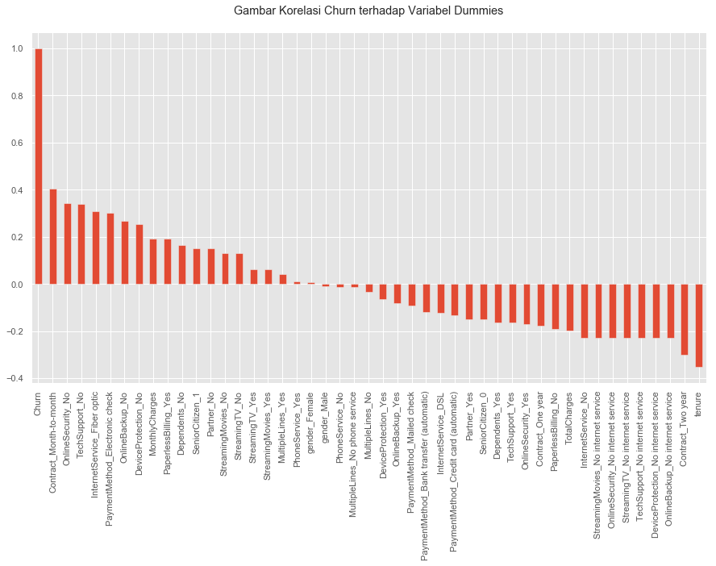

```python
# korelasi Churn dengan variabel dummies
plt.figure(figsize=(15,8))
plt.title('Gambar Korelasi Churn terhadap Variabel Dummies\n')
datadumm.corr()['Churn'].sort_values(ascending = False).plot(kind='bar')
```

Dari Gambar Korelasi antar Variabel Dummies di atas dapat dilihat bahwa:

- Dari contract month to month, customer lebih berpotensi mengalami 0.4 kali churn, sedangkan contract two year lebih sedikit berpotensi churn.
- Dari Online Security No, customer lebih berpotensi mengalami 0.3 kali churn, sedangkan Online Security No Internet Service lebih sedikit berpotensi churn.
- Dari TechSupport No, customer lebih berpotensi mengalami 0.3 kali churn, sedangkan TechSupport Yes lebih sedikit berpotensi churn.

### 2.2.2 Korelasi Antar Variabel Bertipe Numerik

- Matriks korelasi adalah alat penting untuk memahami korelasi antara karakteristik yang berbeda.
- Nilai berkisar dari -1 hingga 1 dan semakin dekat nilainya ke 1 semakin baik korelasi ada antara dua karakteristik.

### a. Korelasi antara variabel bertipe numerik

```python
# korelasi antara variabel bertipe numerik
print('Korelasi antara variabel bertipe numerik')
kornum=datadumm.iloc[:, 0:3].corr()
kornum
```

```
Korelasi antara variabel bertipe numerik
```

|  | tenure | MonthlyCharges | TotalCharges |
| --- | --- | --- | --- |
| tenure | 1.000000 | 0.247900 | 0.825464 |
| MonthlyCharges | 0.247900 | 1.000000 | 0.650864 |
| TotalCharges | 0.825464 | 0.650864 | 1.000000 |

### b. Plot Korelasi variabel bertipe numerik

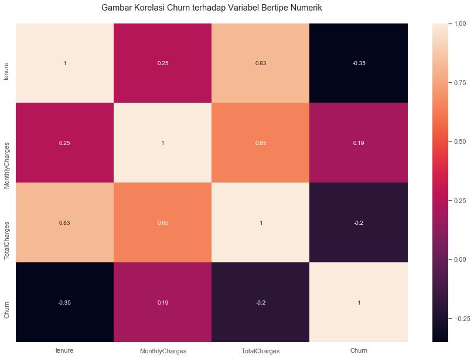

```python
corl=data1.loc[:,:].corr()
plt.figure(figsize = (15,10))
sns.heatmap(corl, annot = True)
plt.title('Gambar Korelasi Churn terhadap Variabel Bertipe Numerik\n')
```

## 2.3 Visualisasi Data

### Boxplot

Boxplot adalah ringkasan distribusi sampel yang disajikan secara grafis yang bisa menggambarkan bentuk distribusi data (skewness), ukuran tendensi sentral dan ukuran penyebaran (keragaman) data pengamatan.  
Terdapat 5 ukuran statistik yang bisa kita baca dari boxplot, yaitu:

- Nilai minimum: nilai observasi terkecil
- Q1: kuartil terendah atau kuartil pertama
- Q2: median atau nilai pertengahan
- Q3: kuartil tertinggi atau kuartil ketiga
- nilai maksimum: nilai observasi terbesar.  
  Selain itu, boxplot juga dapat menunjukkan ada tidaknya nilai outlier dan nilai ekstrim dari data pengamatan

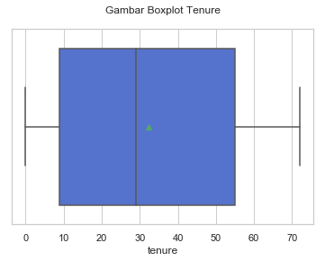

```python
# Boxplot Tenure
data2=data1.loc[:, ['tenure']]
sns.set(style="whitegrid")
ax1=sns.boxplot(x=data2['tenure'], showmeans=True, color='royalblue')
plt.title('Gambar Boxplot Tenure\n')
```

#### Ilustrasi Gambar Boxplot Tenure

- Nilai Minimum : 0
- Q1: 10
- Q2: 30
- Q3: 55
- nilai maksimum: 70,...

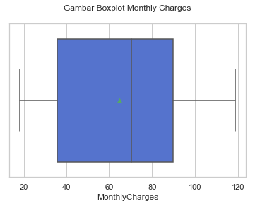

```python
# Boxplot Monthly Charges
data2=data1.loc[:, ['MonthlyCharges']]
sns.set(style="whitegrid")
ax1=sns.boxplot(x=data2['MonthlyCharges'], showmeans=True, color='royalblue')
plt.title('Gambar Boxplot Monthly Charges\n')
```

#### Ilustrasi Gambar Boxplot Monthly Charges

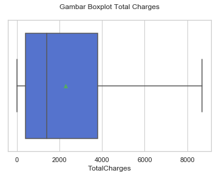

```python
# Boxplot Total Charges
data2=data1.loc[:, ['TotalCharges']]
sns.set(style="whitegrid")
ax1=sns.boxplot(x=data2['TotalCharges'], showmeans=True, color='royalblue')
plt.title('Gambar Boxplot Total Charges\n')
```

### a. Churn

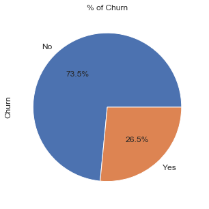

```python
#ax = sns.catplot(y="Churn", kind="count", data=data, height=2.6, aspect=2.5, orient='h')
#plt.title('Churn Rate')

plt.figure(figsize=(10, 4.5))
ax = (data['Churn'].value_counts()*100.0 /len(data))\
.plot.pie(autopct='%.1f%%', labels = ['No', 'Yes'],figsize =(5,5), fontsize = 12 )
ax.yaxis.set_major_formatter(mtick.PercentFormatter())
ax.set_ylabel('Churn',fontsize = 12)
ax.set_title('% of Churn', fontsize = 12)
```

Dapat diketahui dari diagram lingkaran di atas mengenai customer yang mengalami churn di bulan sebelumnya dengan prosentase sebagai berikut:

- Churn: Tidak - 73,5%
- Churn: Ya - 26,5%

### b. Gender and Age (Senior Citizen)

```python
# membuat engine untuk SQLite
from sqlalchemy import create_engine
engine=create_engine('sqlite:///:memory:')
data.to_sql('tabel_telco',engine)
```

```python
def barplot_percentages(feature, orient='v', axis_name="percentage of customers"):
    ratios = pd.DataFrame()
    g = data.groupby(feature)["Churn"].value_counts().to_frame()
    g = g.rename({"Churn": axis_name}, axis=1).reset_index()
    g[axis_name] = g[axis_name]/len(data)
    if orient == 'v':
        ax = sns.barplot(x=feature, y= axis_name, hue='Churn', data=g, orient=orient)
        ax.set_yticklabels(['{:,.0%}'.format(y) for y in ax.get_yticks()])
    else:
        ax = sns.barplot(x= axis_name, y=feature, hue='Churn', data=g, orient=orient)
        ax.set_xticklabels(['{:,.0%}'.format(x) for x in ax.get_xticks()])
    ax.plot()
```

```
  SeniorCitizen Churn  freq
0             0    No  4508
1             0   Yes  1393
2             1    No   666
3             1   Yes   476
```

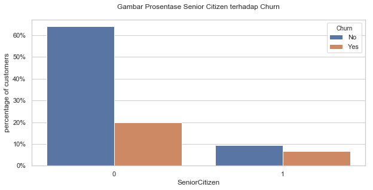

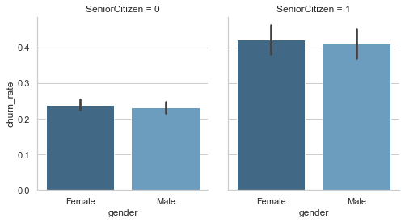

```python
q2=pd.read_sql_query('select SeniorCitizen, churn, count(*) as freq from tabel_telco group by SeniorCitizen, Churn', engine)
print (q2)

plt.figure(figsize=(10, 4.5))
barplot_percentages("SeniorCitizen")
plt.title('Gambar Prosentase Senior Citizen terhadap Churn\n')


data['churn_rate'] = data['Churn'].replace("No", 0).replace("Yes", 1)
g = sns.FacetGrid(data, col="SeniorCitizen", height=4, aspect=.9)
ax = g.map(sns.barplot, "gender", "churn_rate", palette = "Blues_d", order= ['Female', 'Male'])
```

### c. Partner and Dependents

```
  Partner Churn  freq
0      No    No  2441
1      No   Yes  1200
2     Yes    No  2733
3     Yes   Yes   669
```

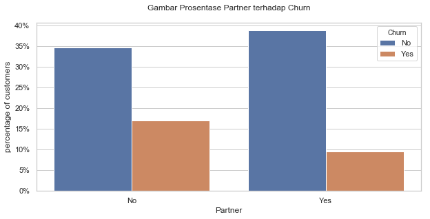

```python
q3=pd.read_sql_query('select Partner, churn, count(*) as freq from tabel_telco group by Partner, churn', engine)
print (q3, '\n')

plt.figure(figsize=(10, 4.5))
barplot_percentages('Partner')
plt.title('Gambar Prosentase Partner terhadap Churn\n')
```

Dari gambar di atas dapat diketahui bahwa:

- Customer yang tidak memiliki partner lebih cenderung untuk churn.

```
  Dependents Churn  freq
0         No    No  3390
1         No   Yes  1543
2        Yes    No  1784
3        Yes   Yes   326
```

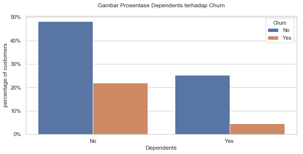

```python
q4=pd.read_sql_query('select Dependents, churn, count(*) as freq from tabel_telco group by Dependents, churn', engine)
print (q4)

plt.figure(figsize=(10, 4.5))
barplot_percentages('Dependents')
plt.title('Gambar Prosentase Dependents terhadap Churn\n')
```

Dari gambar di atas dapat diketahui bahwa:

- Customer yang tidak memiliki dependents juga cederung churn

### d. Multiple Lines (Phone and Internet services)

Multiple Lines adalah customer yang memiliki satu atau lebih saluran layanan. Terdapat dua layanan utama yang dapat didaftarkan oleh customer dari MultipleLines yaitu Phone and Internet services. Selain itu, customer juga dapat memilih layanan tambahan lain seperti online backup dan security. Dalam Multiple Lines terdapat tiga kategori yaitu No (Tidak memiliki saluran), No phone service (tidak memiliki layanan telepon saja), dan Yes (memiliki satu atau lebih saluran).

```
      MultipleLines Churn  freq
0                No    No  2541
1                No   Yes   849
2  No phone service    No   512
3  No phone service   Yes   170
4               Yes    No  2121
5               Yes   Yes   850
```

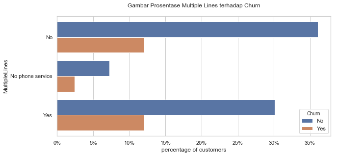

```python
q5=pd.read_sql_query('select MultipleLines, churn, count(*) as freq from tabel_telco group by MultipleLines, churn', engine)
print (q5)

plt.figure(figsize=(10, 4.5))
plt.title('Gambar Prosentase Multiple Lines terhadap Churn\n')
barplot_percentages("MultipleLines", orient='h')
```

Dari gambar di atas dapat diketahui bahwa:

- Sedikit customer yang tidak menggunakan phone service
- Customer yang memiliki MultipleLines tingkat churn yang sedikit lebih tinggi

### e. Internet Service

```
  InternetService Churn  freq
0             DSL    No  1962
1             DSL   Yes   459
2     Fiber optic    No  1799
3     Fiber optic   Yes  1297
4              No    No  1413
5              No   Yes   113
```

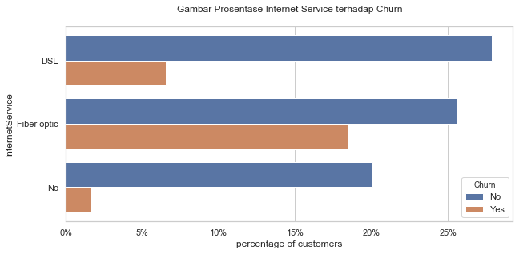

```python
q6=pd.read_sql_query('select InternetService, churn, count(*) as freq from tabel_telco group by InternetService, churn', engine)
print (q6)

plt.figure(figsize=(10, 4.5))
plt.title('Gambar Prosentase Internet Service terhadap Churn\n')
barplot_percentages("InternetService", orient="h")
```

Dari gambar di atas dapat diketahui bahwa:

- Customer yang tidak menggunakan layanan internet memiliki tingkat churn yang rendah
- Customer dengan layanan internet menggunakan fiber lebih memungkinkan untuk churn dibandingkan dengan yang menggunakan DSL

### f. Additional Service

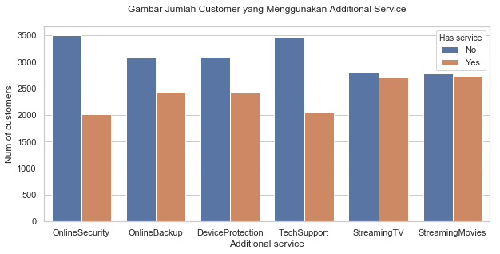

```python
cols = ["OnlineSecurity", "OnlineBackup", "DeviceProtection", "TechSupport", "StreamingTV", "StreamingMovies"]
df1 = pd.melt(data[data["InternetService"] != "No"][cols]).rename({'value': 'Has service'}, axis=1)
plt.figure(figsize=(10, 4.5))
plt.title('Gambar Jumlah Customer yang Menggunakan Additional Service\n')
ax = sns.countplot(data=df1, x='variable', hue='Has service')
ax.set(xlabel='Additional service', ylabel='Num of customers')
plt.show()
```

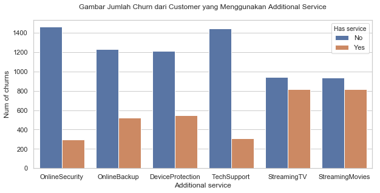

```python
plt.figure(figsize=(10, 4.5))
plt.title('Gambar Jumlah Churn dari Customer yang Menggunakan Additional Service\n')
df1 = data[(data.InternetService != "No") & (data.Churn == "Yes")]
df1 = pd.melt(df1[cols]).rename({'value': 'Has service'}, axis=1)
ax = sns.countplot(data=df1, x='variable', hue='Has service', hue_order=['No', 'Yes'])
ax.set(xlabel='Additional service', ylabel='Num of churns')
plt.show()
```

Plot pertama menunjukkan jumlah total customer untuk setiap additional service, sedangkan yang kedua menunjukkan jumlah customer yang churn. Dari gambar di atas dapat diketahui bahwa:

- Pelanggan dengan 4 layanan tambahan (OnlineSecurity,Online Backup, Device Protection, TechSupport)lebih tidak mungkin untuk churn
- Layanan streaming tidak dapat memprediksi untuk churn

### g. Contract, Paperless Billing, dan Payment

```
   PaperlessBilling        Contract Churn  freq
0                No  Month-to-month    No   883
1                No  Month-to-month   Yes   406
2                No        One year    No   625
3                No        One year   Yes    48
4                No        Two year    No   895
5                No        Two year   Yes    15
6               Yes  Month-to-month    No  1337
7               Yes  Month-to-month   Yes  1249
8               Yes        One year    No   682
9               Yes        One year   Yes   118
10              Yes        Two year    No   752
11              Yes        Two year   Yes    33
```

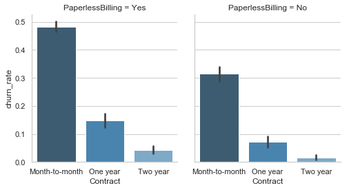

```python
q7=pd.read_sql_query('select PaperlessBilling, Contract,  churn, count(*) as freq from tabel_telco group by PaperlessBilling, Contract, churn', engine)
print (q7)

g = sns.FacetGrid(data, col="PaperlessBilling", height=4, aspect=.9)
ax = g.map(sns.barplot, "Contract", "churn_rate", palette = "Blues_d", order= ['Month-to-month', 'One year', 'Two year'])
```

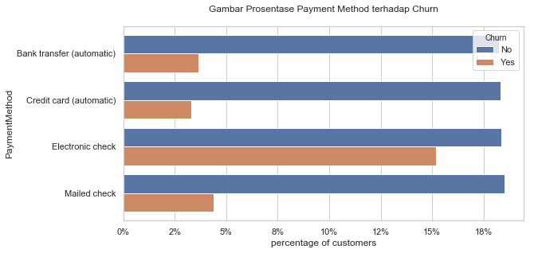

```python
plt.figure(figsize=(9, 4.5))
plt.title('Gambar Prosentase Payment Method terhadap Churn\n')
barplot_percentages("PaymentMethod", orient='h')
```

Dari dua gambar di atas dapat diketahui bahwa:

- Customer yan menggunakan PaperlessBilling lebih memungkinkan untuk churn
- Payment method dengan Electronic check sekitar 35% dari total customer. Method ini memiliki resiko tinggi untuk churn
- Month to month juga memiliki resiko tinggi untuk churn

# 3. Regresi Logistik

Regresi logistik adalah suatu pendekatan untuk membuat model prediksi variabel terikat yang berskala data nominal dengan dua kategori, misalnya: Ya dan Tidak, Baik dan Buruk atau Tinggi dan Rendah..

## 3.1 Memisahkan Data Training dan Data Testing

```python
# memisahkan data training dan data testing
from sklearn.model_selection import train_test_split
x_train, x_test, y_train, y_test = train_test_split(datadumm.drop('Churn',axis=1), datadumm['Churn'], test_size=0.30, random_state=101)
print ('dalam analisis ini, digunakan data testing sebanyak 30% dari dataset dan 70% sisanya adalah data training yang digunakan untuk membangun model')
```

```
dalam analisis ini, digunakan data testing sebanyak 30% dari dataset dan 70% sisanya adalah data training yang digunakan untuk membangun model
```

## 3.2 Membangun Model Prediksi

```python
# membangun model dan prediksi
from sklearn.linear_model import LogisticRegression
logreg=LogisticRegression()
estimasi=logreg.fit(x_train,y_train)
predik=logreg.predict(x_test)
predik
```

```
array([0, 0, 0, ..., 1, 1, 1], dtype=int64)
```

```python
# koefisien parameter untuk tiap variabel variabel dengan tambahan parameter intersep
print ('koefisien parameter', logreg.coef_)
print ('koefisien parameter', logreg.intercept_)
```

```
koefisien parameter [[-6.34249862e-02  3.37683114e-03  3.35730976e-04 -6.54891384e-02
  -3.34104712e-02 -1.54783671e-01  5.58840612e-02 -5.00531814e-02
  -4.88464282e-02  2.88824733e-02 -1.27782083e-01  1.33650905e-01
  -2.32550515e-01 -2.02528579e-01  1.33650905e-01 -3.00219355e-02
  -3.16604690e-01  2.93110182e-01 -7.54051019e-02  1.83316882e-01
  -7.54051019e-02 -2.06811390e-01  1.18728223e-01 -7.54051019e-02
  -1.42222731e-01  3.88244451e-02 -7.54051019e-02 -6.23189528e-02
   2.28029230e-01 -7.54051019e-02 -2.51523738e-01 -1.31582103e-01
  -7.54051019e-02  1.08087595e-01 -7.74872850e-02 -7.54051019e-02
   5.39927773e-02  3.94658620e-01 -1.37981617e-01 -3.55576613e-01
  -2.35262445e-01  1.36362835e-01 -1.06046506e-01 -1.98575480e-01
   2.83328504e-01 -7.76061270e-02]]
koefisien parameter [-0.09889961]
```

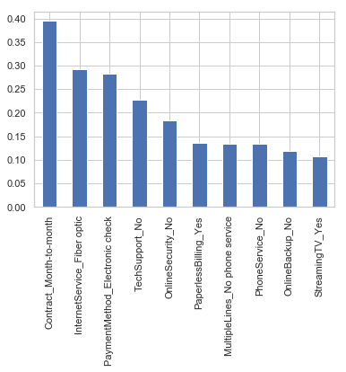

```python
bobot=pd.Series(logreg.coef_[0], index=datadumm.drop('Churn', axis=1).columns.values)
bobot.sort_values(ascending=False)[:10].plot(kind='bar')
```

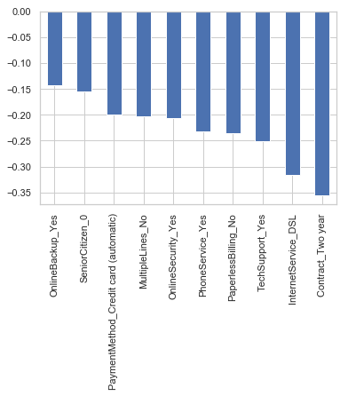

```python
bobot.sort_values(ascending=False)[-10:].plot(kind='bar')
```

Dari dua gambar di atas dapat diketahui bahwa:

- Terdapat beberapa variabel yang memiliki hubungan negatif dengan variabel prediksi(Churn), sementara variabel yang lain memiliki hubungan positif. Hubungan negatif berarti kemungkinan churn berkurang dengan variabel itu.
- Seperti yang terdapat di EDA, customer yang memiliki contact two years mengurangi peluang churn. Contract two years memiliki hubungan paling negatif dengan Churn seperti yang diperkirakan oleh regresi logistik.
- Customer dengan layanan internet DSL juga mengurangi probabilitas Churn. Terakhir, total charge, contract month to month, Internet Service fiber optic dan Senior Citizen menyebabkan tingkat churn yang lebih tinggi.

## 3.3 Menguji Kebaikan Model Prediksi

### a. Confusion Matrix

Confusion matrix digunakan untuk menunjukkan ketepatan dalam mengklasifikasi sesuai dengan model yang ada.

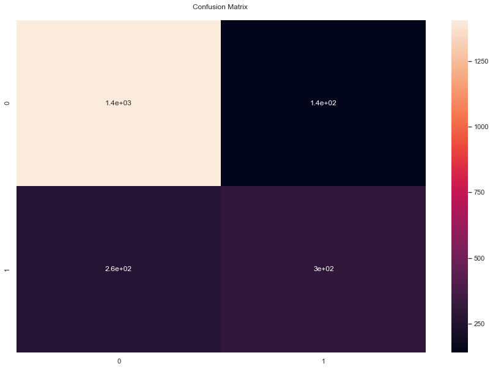

```python
from sklearn.metrics import confusion_matrix
cm=confusion_matrix(y_test, predik)
plt.figure(figsize = (15,10))
sns.heatmap(cm, annot = True)
plt.title('Confusion Matrix \n')
# true positive (tp) = 1406, true negative = 302, false positive = 140, false negative = 265
```

### b. Accuracy, Precision dan Recall

- Accuracy adalah rasio prediksi klasifikasi yang benar (positif dan negatif) dengan keseluruhan data.
- Precision adalah rasio prediksi benar positif dibandingkan dengan keseluruhan hasil yang diprediksi positif.
- Recall disebut juga sensitivitas adalah rasio prediksi benar positif dibandingkan dengan keseluruhan data yang benar positif

```python
# kriteria kebaikan model prediksi
from sklearn import metrics
print ("Accuracy:", metrics.accuracy_score(y_test, predik))
print ("Precision:", 1406/(1406+140))
print ("Recall:", 1406/(1406+265))
```

```
Accuracy: 0.808329389493611
Precision: 0.9094437257438551
Recall: 0.8414123279473369
```

## 3.4 Interpretasi Model

```python
print (logreg.predict_proba(x_test))
print ('dalam regresi logistik, hasil persamaan regresi merupakan sebuah nilai probabilitas.')
print ('dalam kasus ini, maka persamaan regresi merupakan peluang seorang customer melakukan churn atau tidak')
```

```
[[0.95313687 0.04686313]
 [0.53505848 0.46494152]
 [0.76498981 0.23501019]
 ...
 [0.44787298 0.55212702]
 [0.31565626 0.68434374]
 [0.48529295 0.51470705]]
dalam regresi logistik, hasil persamaan regresi merupakan sebuah nilai probabilitas.
dalam kasus ini, maka persamaan regresi merupakan peluang seorang customer melakukan churn atau tidak
```

## 3.7 Saran

Penyedia layanan telekomunikasi tersebut dapat memperkirakan customer-customer yang memiliki peluang untuk churn, sehingga dapat diterapkan strategi tertentu untuk mencegah churn yang dilakukan oleh customer. Baik berupa strategi pemasaran, customer relationship, fitur-fitur yang didapat pelanggan, maupun jaminan atas kendala/crash yang mungkin dirasakan oleh pelanggan terkait pemakaian jasa perusahaan.